# Beer Reviews Analysis

Yang Peng

23 September 2018

## Summary of the Dataset

This dataset consists of approximately 1.5 million beer reviews from Beer Advocate.

Number of Instances:

```r
dim(beer.reviews)[1]
```

```
## [1] 1586614
```

Number of Attributes:

```r
dim(beer.reviews)[2]
```

```
## [1] 13
```

Dataset example:

```r
kable(beer.reviews[1:5,])
```

| brewery_id | brewery_name | review_time | review_overall | review_aroma | review_appearance | review_profilename | beer_style | review_palate | review_taste | beer_name | beer_abv | beer_beerid |
| --- | --- | --- | --- | --- | --- | --- | --- | --- | --- | --- | --- | --- |
| 10325 | Vecchio Birraio | 1234817823 | 1.5 | 2.0 | 2.5 | stcules | Hefeweizen | 1.5 | 1.5 | Sausa Weizen | 5.0 | 47986 |
| 10325 | Vecchio Birraio | 1235915097 | 3.0 | 2.5 | 3.0 | stcules | English Strong Ale | 3.0 | 3.0 | Red Moon | 6.2 | 48213 |
| 10325 | Vecchio Birraio | 1235916604 | 3.0 | 2.5 | 3.0 | stcules | Foreign / Export Stout | 3.0 | 3.0 | Black Horse Black Beer | 6.5 | 48215 |
| 10325 | Vecchio Birraio | 1234725145 | 3.0 | 3.0 | 3.5 | stcules | German Pilsener | 2.5 | 3.0 | Sausa Pils | 5.0 | 47969 |
| 1075 | Caldera Brewing Company | 1293735206 | 4.0 | 4.5 | 4.0 | johnmichaelsen | American Double / Imperial IPA | 4.0 | 4.5 | Cauldron DIPA | 7.7 | 64883 |

## Five number summarys

```r
summary(beer_abv)
```

```
##    Min. 1st Qu.  Median    Mean 3rd Qu.    Max.    NA's
##    0.01    5.20    6.50    7.04    8.50   57.70   67785
```

```r
summary(review_overall)
```

```
##    Min. 1st Qu.  Median    Mean 3rd Qu.    Max.
##   0.000   3.500   4.000   3.816   4.500   5.000
```

```r
summary(review_aroma)
```

```
##    Min. 1st Qu.  Median    Mean 3rd Qu.    Max.
##   1.000   3.500   4.000   3.736   4.000   5.000
```

```r
summary(review_appearance)
```

```
##    Min. 1st Qu.  Median    Mean 3rd Qu.    Max.
##   0.000   3.500   4.000   3.842   4.000   5.000
```

```r
summary(review_palate)
```

```
##    Min. 1st Qu.  Median    Mean 3rd Qu.    Max.
##   1.000   3.500   4.000   3.744   4.000   5.000
```

```r
summary(review_taste)
```

```
##    Min. 1st Qu.  Median    Mean 3rd Qu.    Max.
##   1.000   3.500   4.000   3.793   4.500   5.000
```

From the summary above, we know that there are many missing values in beer_abv and the review score is ranging from 0 to 5.

## Data Cleaning and Checking

Check the count of missing or empty values for beer_abv and brewery_name in Qestion 1:

```r
sum(is.na(beer_abv)|beer_abv=="")
```

```
## [1] 67785
```

```r
sum(is.na(brewery_name)|brewery_name=="")
```

```
## [1] 15
```

Remove NA values and save into d2:

```r
d2 <- na.omit(beer.reviews)#remove rows contains NA value
dim(d2)
```

```
## [1] 1518829      13
```

```r
(dim(beer.reviews)[1]-dim(d2)[1])/dim(beer.reviews)[1] #check the percent of the removed rows.
```

```
## [1] 0.04272306
```

It shows that the cleaned parts is less than 5%, so we used the cleaned dataset d2 for the following analysis.

Check the length of unique brewery_name and brewery_id:

```r
length(unique(d2$brewery_name))
```

```
## [1] 5156
```

```r
length(unique(d2$brewery_id))
```

```
## [1] 5232
```

It turns out the number of unique brewey_id is greater than the number of unique brewery_name, which means different id may have same brewery_name. It can be caused by cutting off by the length of charater.Same as beer_id and beer_name:

```r
length(unique(d2$beer_name))
```

```
## [1] 44085
```

```r
length(unique(d2$beer_beerid))
```

```
## [1] 49012
```

So here I used brewery_id and beer_beerid as the index of different categories.

## 1. Which brewery produces the strongest beers by ABV%?

Find the average beer_adv group by brewery_id:

```r
a <- aggregate(d2$beer_abv, list(d2$brewery_id), mean,na.omit=T)
dim(a)
```

```
## [1] 5232    2
```

Find the unique brewery name which has the max beer_abv:

```r
ii <- a$Group.1[a$x==max(a$x)]
unique(d2$brewery_name[d2$brewery_id==ii])#[1] SchorschbrÃ¤u
```

```
## [1] SchorschbrÃ¤u
## 5743 Levels:  't Hofbrouwerijke ... Zywiec Breweries PLC (Heineken)
```

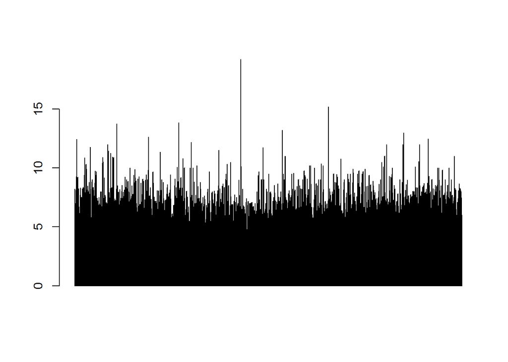

```r
barplot(a$x)
```

It shows Schorschbräu has the max beer ABV% and we can see from the barplot that only one brewery has the noticeable highest abv, which is Schorschbräu. **So Schorschbräu produces the strongest beers by ABV%.**

## 2. If you had to pick 3 beers to recommend using only this data, which would you pick?

Find the review frequency histogram group by beer_beerid:

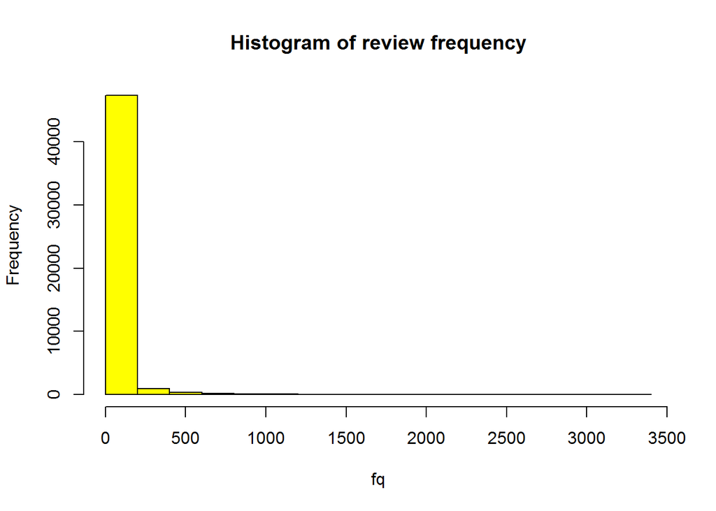

```r
fq <- table(d2$beer_beerid)
hist(fq,col="yellow",breaks = 20,main="Histogram of review frequency")
```

Use mean review_overall to determine the popularity:

```r
table(d2$review_overall)
```

```
##
##      0      1    1.5      2    2.5      3    3.5      4    4.5      5
##      7  10211  12035  35755  54696 155902 286972 559869 314365  89017
```

There are 89017 reviews has 5.

Find the average review_overall group by beer_beerid. Plot for “mean review_overall” vs “review frequency”:

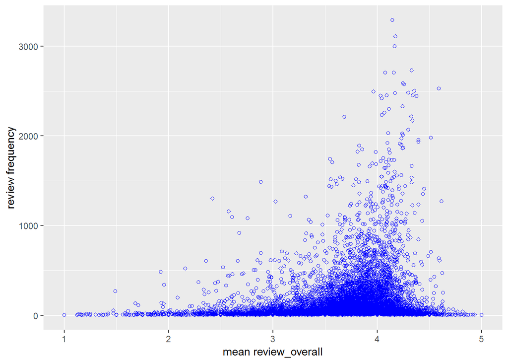

```r
b <- aggregate(d2$review_overall, list(d2$beer_beerid), mean,na.omit=T)
t <- as.data.frame(cbind(b[,2],fq))
colnames(t) <- c("mean review_overall","review frequency")
ggplot(t, aes(x=`mean review_overall`, y=`review frequency`)) + geom_point(shape=1,color="blue")
```

A good beer should has a reasonable amount of reviews and has a high review score as well. In other words, large number of the reviews, large mean of the review_overall and small variance of review_overall consist of the criterion of ranking beers.

So, here I used the lower bound of 95% confidence interval as the measurement of ranking beers:x_bar-t*sd/sqrt(n).

Moreover, the number of reviews cannot be too small, based on the scatter plot above, here I use 100 as the threshold:

```r
ss <- split.data.frame(d2[,c(4,13)],d2$beer_beerid)

getCI <- function(x){
  if(dim(x)[1]<100){
    lowci=0
  }else{
    b <- t.test(x$review_overall)
    lowci <- b$conf.int[1]
  }

}

top3 <- sort(sapply(ss,getCI),decreasing = T)[1:3]
unique(d2$beer_name[d2$beer_beerid %in% names(top3)])
```

```
## [1] Citra DIPA               Heady Topper
## [3] Trappist Westvleteren 12
## 56857 Levels: '55' Lager '71 Pale Ale ... ZZ Lager
```

**It shows that “Citra DIPA”, “Heady Topper” and “Trappist Westvleteren 12” are the three beers that I want to recommended based on this dataset.**

## 3. Which of the factors (aroma, taste, appearance, palette) are most important in determining the overall quality of a beer?

First, I used the correlations between these fators to figure out which one is most important:

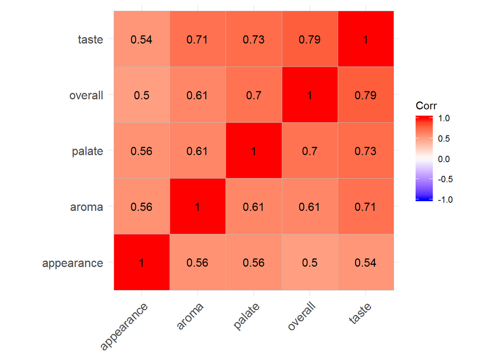

```r
reviewMt <- cbind(d2$review_overall,d2$review_aroma,d2$review_appearance,d2$review_palate,d2$review_taste)
revcor <-round(cor(reviewMt),2)
colnames(revcor) <- rownames(revcor) <- c("overall","aroma","appearance","palate","taste")
ggcorrplot(revcor, hc.order = TRUE,lab = TRUE)
```

From the correlation heat plot we can see that taste is the most important.

Second, I incoporate linear model and t-test to support the above result:

```r
# fit a linear model for diff reviews
lmfit <- lm(d2$review_overall~d2$review_aroma+d2$review_appearance+d2$review_palate+d2$review_taste)
summary(lmfit)
```

```
##
## Call:
## lm(formula = d2$review_overall ~ d2$review_aroma + d2$review_appearance +
##     d2$review_palate + d2$review_taste)
##
## Residuals:
##     Min      1Q  Median      3Q     Max
## -3.8681 -0.2570 -0.0067  0.2453  3.6610
##
## Coefficients:
##                       Estimate Std. Error t value Pr(>|t|)
## (Intercept)          0.4477379  0.0023713  188.82   <2e-16 ***
## d2$review_aroma      0.0476247  0.0007406   64.31   <2e-16 ***
## d2$review_appearance 0.0357281  0.0007168   49.84   <2e-16 ***
## d2$review_palate     0.2579818  0.0007785  331.37   <2e-16 ***
## d2$review_taste      0.5498900  0.0007957  691.08   <2e-16 ***
## ---
## Signif. codes:  0 '***' 0.001 '**' 0.01 '*' 0.05 '.' 0.1 ' ' 1
##
## Residual standard error: 0.4219 on 1518824 degrees of freedom
## Multiple R-squared:  0.6541, Adjusted R-squared:  0.6541
## F-statistic: 7.18e+05 on 4 and 1518824 DF,  p-value: < 2.2e-16
```

Based on the p-value and t-statistic can also get the same conclusion.

The 65.41% R-square is not satisfactory. Since Review score is from 0 to 5, I transformed the review_overall to be from -Inf to Inf and refit linear model to see if it can improve R-square:

```r
y1 <- d2$review_overall/5
y <- log((y1+0.001)/(1.001-y1))
lmfit3 <- lm(y~d2$review_aroma+d2$review_appearance+d2$review_palate+d2$review_taste)
summary(lmfit3)
```

```
##
## Call:
## lm(formula = y ~ d2$review_aroma + d2$review_appearance + d2$review_palate +
##     d2$review_taste)
##
## Residuals:
##     Min      1Q  Median      3Q     Max
## -7.2429 -0.5635 -0.2687  0.1513  9.2574
##
## Coefficients:
##                       Estimate Std. Error t value Pr(>|t|)
## (Intercept)          -3.744288   0.006856 -546.16   <2e-16 ***
## d2$review_aroma       0.062739   0.002141   29.30   <2e-16 ***
## d2$review_appearance  0.095146   0.002072   45.91   <2e-16 ***
## d2$review_palate      0.441914   0.002251  196.33   <2e-16 ***
## d2$review_taste       0.795824   0.002300  345.94   <2e-16 ***
## ---
## Signif. codes:  0 '***' 0.001 '**' 0.01 '*' 0.05 '.' 0.1 ' ' 1
##
## Residual standard error: 1.22 on 1518824 degrees of freedom
## Multiple R-squared:  0.3493, Adjusted R-squared:  0.3493
## F-statistic: 2.038e+05 on 4 and 1518824 DF,  p-value: < 2.2e-16
```

Since the R-square reduced to 35%, such transformation is not successful for the model fitting.

Lastly, I fit a nonlinear model, Random Forest, to vote for the most important factor:

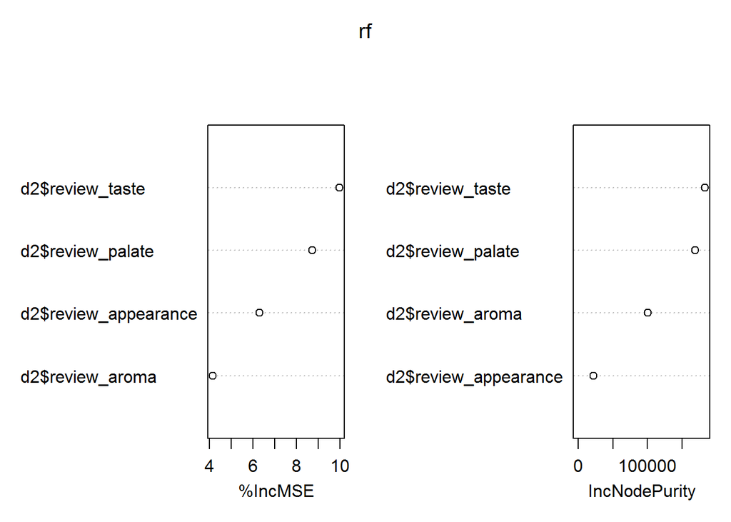

```r
rf <- randomForest(d2$review_overall~d2$review_aroma+d2$review_appearance+d2$review_palate+d2$review_taste,
                    importance=TRUE,
                    ntree=20)
varImpPlot(rf)
```

The plot above also indicates the variable taste to be the most important factor, which is consistent with the finding in linear model.

**In sum, taste is the most important fator based on all the analysis above.**

## 4. Lastly, if I typically enjoy a beer due to its aroma and appearance, which beer style should I try?

Add a new column “subtol2” as the sum of review_aroma and review_appearance into d2:

```r
subtol2 <- d2$review_aroma+d2$review_appearance
d2$subtol2 <- subtol2
```

Find the average of “subtol2” group by beer style and get the one with maximum subtotal of review_aroma and review_appearance :

```r
ff <- aggregate(d2$subtol2, list(d2$beer_style), mean,na.omit=T)
gg <- ff[ff$x==max(ff$x),]
gg
```

```
##                             Group.1        x
## 12 American Double / Imperial Stout 8.325858
```

```r
dim(d2[d2$beer_style==gg$Group.1,])[1]
```

```
## [1] 50146
```

Due to the large amount of reviews for American Double / Imperial Stout, the finding is convincing.

**American Double / Imperial Stout is recommended if you typically enjoy a beer due to its aroma and appearance.**